# Calculating climate velocities

#### 2. Distanced-based climate velocities

Distanced-based climate velocities (dVoCC) identify local environments that have future climatic conditions analogous to the baseline conditions at a location of interest, and then estimate the distance and direction between the location of interest and its future analogue. They are calculated as the geographical distance to the closest climate analogue for divided by the time elapsed between baseline and future periods:

**dVoCC = distance to climate analogue / time between analogous climates**

dVoCC measurements depend on both the algorithm used to identify climate analogues, and the threshold used to define an “analogous climate”. The algorithm decides a climate is analogous if deviations from the baseline climate remain within the threshold (defined by you). Defining these thresholds can be quite subjective, and can be especially difficult when multiple climate variables (e.g., temperature and rainfall) are used together. In these cases, algorithms might found that no climate analogues actually exist. A logical way to define the thresholds is based on natural variation in baseline conditions. For example, it would make sense to say a climate is not an analogue to another if its conditions have deviated more than one standard deviation from those in a baseline period of the climate of interest.

Let’s calculate dVoCC. To find analogous climates, we need data with high spatial resolution. For this, we will use a data set that is built in to the VoCC package.

```r
## learn about data
?JapTC
```

Now, we need to make a very specifically structured data frame as input. The first column must be a climate variable at the present time, the second column must be the same variable at a future time. For now, let’s only use mean annual precipitation as our variable of interest (`AnMn`):

```r
## extract values from cells and format
clim_df <- na.omit(data.frame(AnMn_hist = getValues(JapTC$AnMnPpr60_69),
                           AnMn_fut = getValues(JapTC$AnMnPpr08_17),
                           cid = 1:ncell(JapTC)))
clim_df[,c("x","y")] <- xyFromCell(JapTC, clim_df$cid)
```

Now we can run the `dVoCC` function:

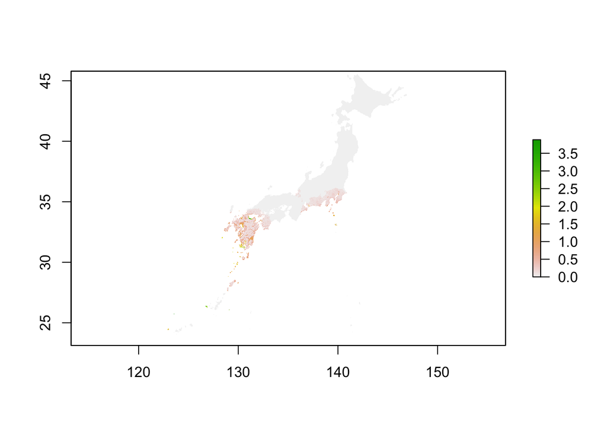

```r
## now we can run the dVoCC function
dvocc  = dVoCC(clim = clim_df,
               n = 1, # number of climate variables (for now we are only using precipitation)
               tdiff = 40, # number of years between time periods
               method = "Single", # specificy that all cells will have the same threshold to be analgous
               distfun = "GreatCircle", # specify function used to calculate distances to climate analogues
               lonlat = TRUE, # not projected coordinates
               geoTol = 160, # set max distance to analogue
               climTol = 10 # set threshold to 10 mm deviation in precipitation
)

## plot
r <- raster(JapTC)
r[dvocc$focal] <- dvocc$vel
plot(r)
```

Let’s try making the analgoue threshold location-specific. To do this, we need to add a third column describing the threshold for each cell and change the `method` argument to `"Variable"`. In this case, we can use the standard deviation of precipitation:

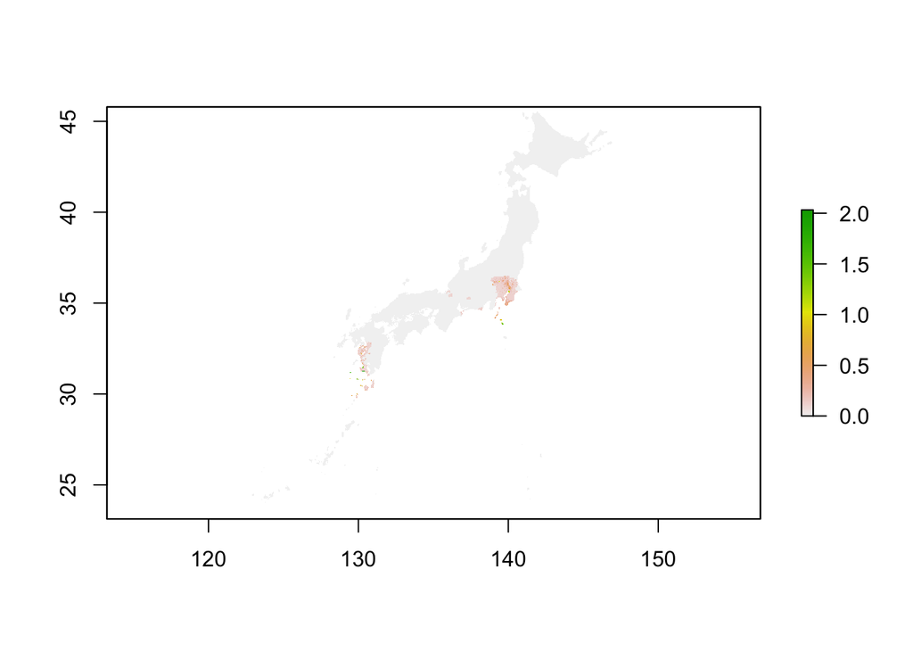

```r
## extract values from cells and format
clim_df <- na.omit(data.frame(AnMn_hist = getValues(JapTC$AnMnPpr60_69),
                           AnMn_fut = getValues(JapTC$AnMnPpr08_17),
                           AnMn_sd = getValues(JapTC$AnMnSDPpr60_69),
                           cid = 1:ncell(JapTC)))
clim_df[,c("x","y")] <- xyFromCell(JapTC, clim_df$cid)

## now we can run the dVoCC function
dvocc_thresh  = dVoCC(clim = clim_df,
               n = 1, # number of climate variables (for now we are only using precipitation)
               tdiff = 40, # number of years between time periods
               method = "Variable", # specificy that all cells will have different thresholds
               distfun = "GreatCircle", # specify function used to calculate distances to climate analogues
               lonlat = TRUE, # not projected coordinates
               geoTol = 160, # set max distance to analogue
               climTol = NA
)

## plot
r_thresh <- raster(JapTC)
r_thresh[dvocc_thresh$focal] <- dvocc_thresh$vel
plot(r_thresh)
```

Now, let’s add more variables. We also have maximum and minimum temperature (`Tmax` and `Tmin`).

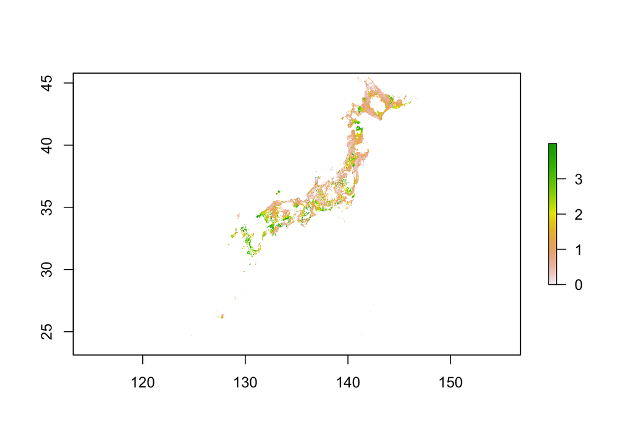

```r
## extract values from cells and format
clim_df <- na.omit(data.frame(AnMn_hist = getValues(JapTC$AnMnPpr60_69),
                           AnMn_fut = getValues(JapTC$AnMnPpr08_17),
                           Tmax_hist = getValues(JapTC$AnMnTmax60_69),
                           Tmax_fut = getValues(JapTC$AnMnTmax08_17),
                           Tmin_hist = getValues(JapTC$AnMnTmin60_69),
                           Tmin_fut = getValues(JapTC$AnMnTmin08_17),
                           cid = 1:ncell(JapTC)))
clim_df[, c("x","y")] <- xyFromCell(JapTC, clim_df$cid)

## now we can run the dVoCC function
dvocc_multi  = dVoCC(clim = clim_df,
               n = 3, # number of climate variables: now 3
               tdiff = 40, # number of years between time periods
               method = "Single", # specificy that all cells will have same threshold
               distfun = "GreatCircle", # specify function used to calculate distances to climate analogues
               lonlat = TRUE, # not projected coordinates
               geoTol = 160, # set max distance to analogue
               climTol = c(10, 0.1, 0.1) # set 10mm threshold for precip, 0.1C threshold for temp
)

## plot
r_multi = raster(JapTC)
r_multi[dvocc_multi$focal] <- dvocc_multi$vel
plot(r_multi)
```

The function’s argument `geoTol` can be used to specific a certain distance that a climate analogue cell must be within from the focal cell. This argument can be useful in understanding how organisms with different dispersal distances might be able to find. An organism with a small dispersal distance (low `geoTol`) might not be able to find a climate analog, whereas an organism with a large dispersal distance (high `geoTol`) in the same location might.

Let’s compare those situations:

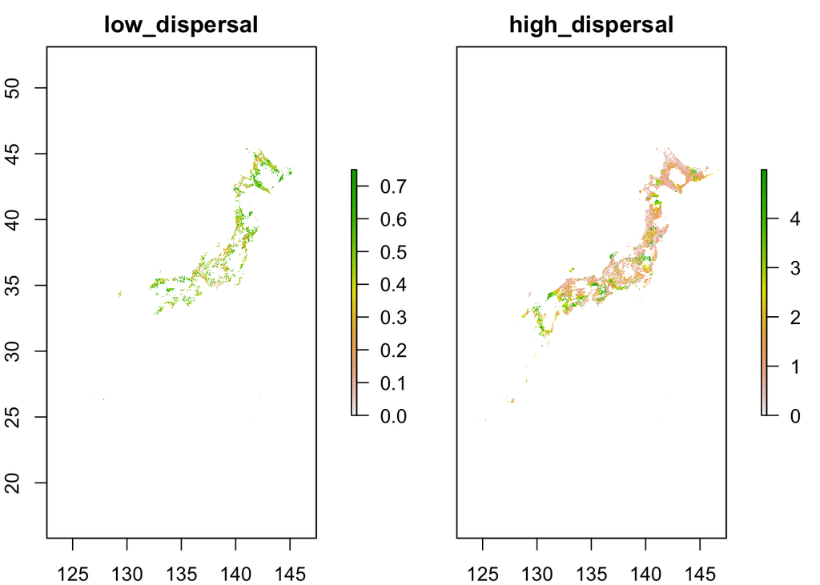

```r
## low dispersal distance:
## use multi variable climate data
dvocc_lowdisp  = dVoCC(clim = clim_df,
               n = 3, # number of climate variables: now 3
               tdiff = 40, # number of years between time periods
               method = "Single", # specificy that all cells will have same threshold
               distfun = "GreatCircle", # specify function used to calculate distances to climate analogues
               lonlat = TRUE, # not projected coordinates
               geoTol = 30, # set max distance to analogue
               climTol = c(10, 0.1, 0.1) # set 10mm threshold for precip, 0.1C threshold for temp
)
## high dispersal distance:
dvocc_highdisp  = dVoCC(clim = clim_df,
               n = 3, # number of climate variables: now 3
               tdiff = 40, # number of years between time periods
               method = "Single", # specificy that all cells will have same threshold
               distfun = "GreatCircle", # specify function used to calculate distances to climate analogues
               lonlat = TRUE, # not projected coordinates
               geoTol = 200, # set max distance to analogue
               climTol = c(10, 0.1, 0.1) # set 10mm threshold for precip, 0.1C threshold for temp
)

## plot
r_lowdisp = raster(JapTC)
r_lowdisp[dvocc_lowdisp$focal] <- dvocc_lowdisp$vel

r_highdisp = raster(JapTC)
r_highdisp[dvocc_highdisp$focal] <- dvocc_highdisp$vel

disp = stack(r_lowdisp, r_highdisp)
names(disp) = c("low_dispersal", "high_dispersal")

plot(disp)
```

Now let’s plot all the places where a species with poor dispersal ability would not be able to reach a climate analogue, but a species with good dispersal ability would:

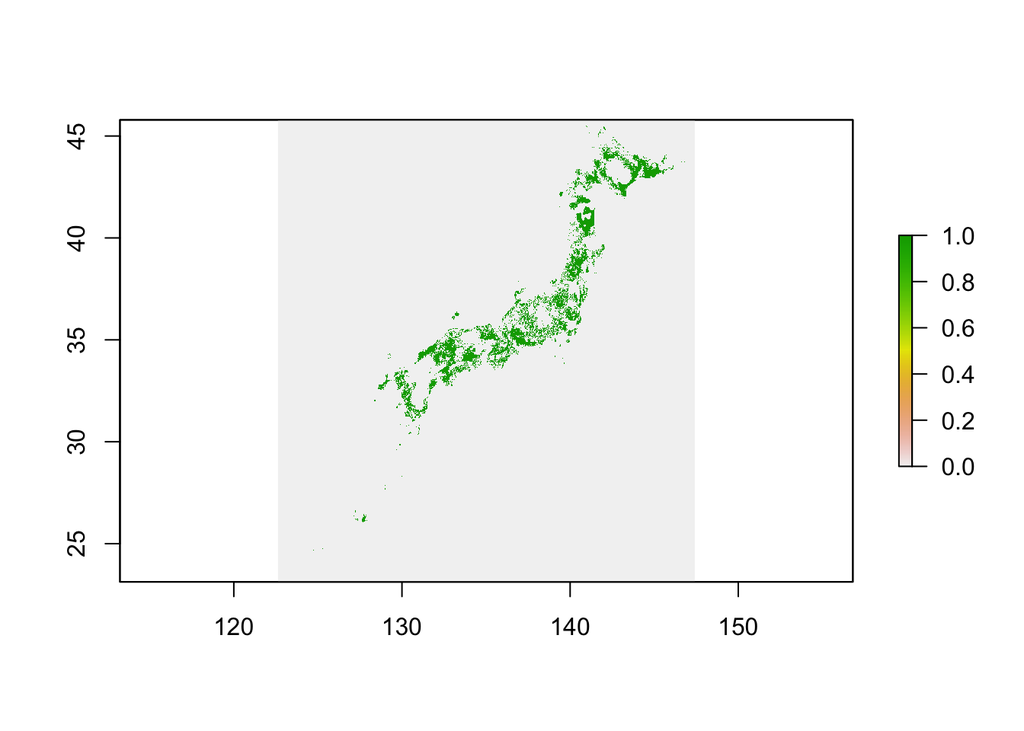

```r
## plot places where r_lowdisp is NA but r_highdisp is not
plot(is.na(r_lowdisp) & !is.na(r_highdisp))
```

*This tutorial was developed by Nikki Moore for the BIOS2 working group “Assessing the potential for climate-driven range shifts through multiple landscapes features across the Canada-US border” based on information found in Molinos et al. 2019 (*DOI: 10.1111/2041-210X.13295*).*